# Normalización, escalamiento y reducción de dimensionalidad

Por qué las decisiones de hoy determinan lo que vamos a poder interpretar en las próximas tres clases

Dr. Danilo Ceschin

Bioinformática y Estadística 3 · Licenciatura en Ciencias Genómicas

Clase 1 de 4 · 8 de septiembre de 2026

## El pipeline de scRNA-seq

Dónde estamos

Las cuatro clases de este módulo cubren los pasos **2 a 6**, sobre su propio conjunto de datos.

**1 · Preprocesamiento y control de calidad**  
Matriz de conteos, filtrado, doublets, RNA ambiental. — Lo rehacemos en 10 min al inicio de hoy

**2 · Normalización, selección de genes, escalamiento**  
Hacer comparables las células entre sí. — **HOY**

**3 · Reducción de dimensionalidad**  
PCA, y sobre él t-SNE y UMAP. — **HOY**

**4 · Clustering y expresión diferencial**  
Agrupar y buscar genes característicos. — Clase 2

**5 · Anotación celular**  
Ponerle nombre biológico a cada grupo. — Clase 3

**6 · Análisis multimodal**  
Agregar la medición de proteína de superficie. — Clase 4

## Del conteo crudo al espacio de trabajo

Primera parte

Control de calidad, normalización, selección de genes y escalamiento: cuatro decisiones antes de mirar nada.

## Umbrales adaptativos por MAD, no constantes de tutorial

Control de calidad · en los datos del curso

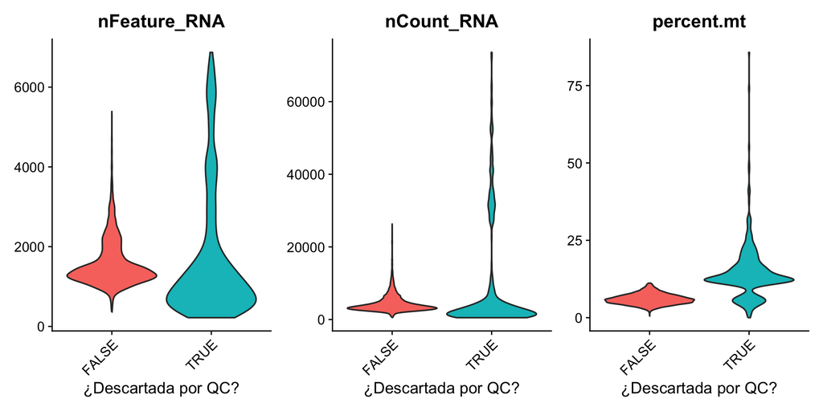

Las 7.856 células que entran al control de calidad, separadas por si el filtro las descarta (7.494 se quedan, 362 se van). El umbral no se copia de ningún tutorial: sale de la mediana y la desviación absoluta mediana de ESTOS datos — 5 MADs para conteos y genes, 3 para el porcentaje mitocondrial, más un tope absoluto de seguridad.

## Los conteos crudos no son comparables entre células

El problema

Dos células con el mismo estado biológico pueden tener números de lecturas muy distintos.

3,7×más lecturas tiene la célula del percentil 95 que la del percentil 5, en estos datos

95,3 %de las entradas de la matriz son cero: la mayoría de los genes no se detecta en la mayoría de las células

~10 %del ARNm de una célula llega a convertirse en cDNA secuenciado

Si comparamos conteos crudos, lo que vamos a medir es **cuánto se secuenció cada célula**. No qué le pasa a cada célula.

## Profundidad y complejidad van juntas, y ninguna es biología

El problema · en los datos del curso

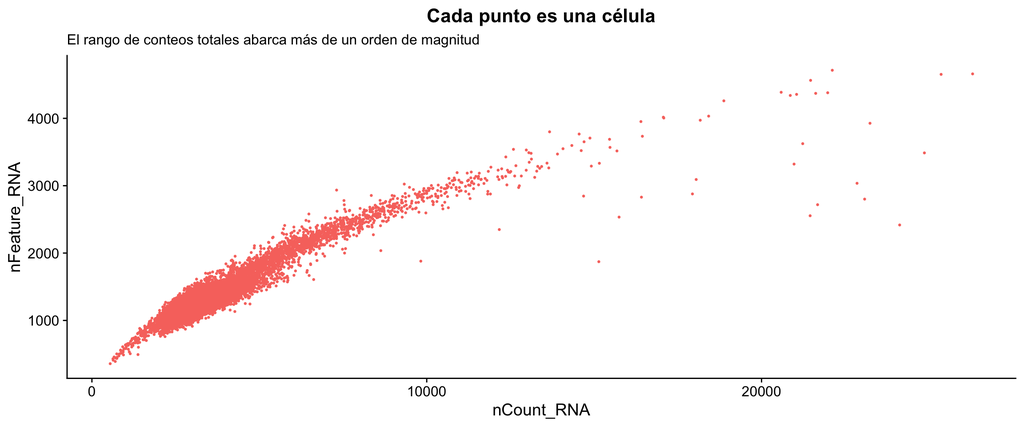

Cada punto es una célula. Las que tienen más lecturas detectan más genes: la relación es fuertísima y no dice nada sobre el tipo celular. Si no se corrige, el eje dominante del análisis va a ser cuánto se secuenció cada célula.

## Normalizar y escalar no son lo mismo

Precisión conceptual

Entre células

#### Normalizar

Corrige diferencias de **profundidad de secuenciación** y de eficiencia de captura.

*“¿cuánto de este gen hay en esta célula, relativo al total de la célula?”*

`NormalizeData()` · `SCTransform()`

Entre genes

#### Escalar

Iguala el **peso de cada gen** para que PCA no quede dominada por los muy expresados.

*“¿esta célula está por encima o por debajo de la media para este gen?”*

`ScaleData()`

Confundirlas es el error conceptual más frecuente de esta parte del pipeline. Son correcciones **ortogonales** y ambas hacen falta.

## LogNormalize: el caballito de batalla

Método 1

Tres operaciones, un solo supuesto fuerte.

[figure not shown]

1. **Dividir por el total de la célula** — cada célula pasa a sumar 1: de conteos a fracciones.
2. **Multiplicar por 10.000** *(counts per 10K)* — el factor es arbitrario; solo evita números diminutos.
3. **Aplicar `log(1 + x)`** — comprime la cola derecha y vuelve multiplicativas las diferencias.

El supuesto

#### El ARN total por célula es ruido técnico

Y a veces es falso. Un plasmablasto tiene genuinamente mucho más ARN que un linfocito en reposo. Una célula en mitosis, también. Al dividir por el total, esa diferencia real desaparece.

El **pseudoconteo (+1)** tampoco es inocente: introduce un sesgo dependiente de la profundidad, sobre todo en genes de baja expresión.

## SCTransform v2: modelar en vez de dividir

Método 2

En vez de un factor de escala por célula, un modelo estadístico por gen.

[figure not shown]

Ajusta una **regresión binomial negativa regularizada** gen por gen, modelando la relación media–varianza. Devuelve **residuos de Pearson**: cuánto se aparta cada célula de lo que el modelo predice para ese gen *a esa profundidad*.

No necesita pseudoconteo · no sobre-corrige los genes bajos · crea su propio assay `"SCT"`.

A favor

#### Mejor comportamiento estadístico

Sobre todo con profundidades muy heterogéneas entre células.

En contra

#### Más lento y menos transparente

Los valores son residuos, no expresión.

**Corre las dos y compara.** Si las conclusiones cambian según la normalización, esa fragilidad es en sí misma un resultado.

## Genes altamente variables (HVGs)

Selección de features

De ~20.000 genes medidos, la mayoría no distingue nada.

Nos quedamos con los genes cuya varianza **excede lo esperable dado su nivel medio de expresión**.

El *“dado su nivel medio”* es la clave: en datos de conteo los genes muy expresados son automáticamente más variables. El método `vst` ajusta esa relación y busca los que se salen de la curva.

`nfeatures = 2000` es el valor por defecto de Seurat. Es una convención, no un resultado.

Malentendido frecuente

#### ¿CD3E no es un HVG?

Es habitual que marcadores canónicos excelentes no aparezcan entre los genes más variables.

No es un problema: los HVGs sirven para **construir el espacio**, no para anotar.

Pero tenlo presente cuando el clustering “no separa” una población que esperabas ver.

## Los 2.000 genes que van a definir el espacio

Selección de features · en los datos del curso

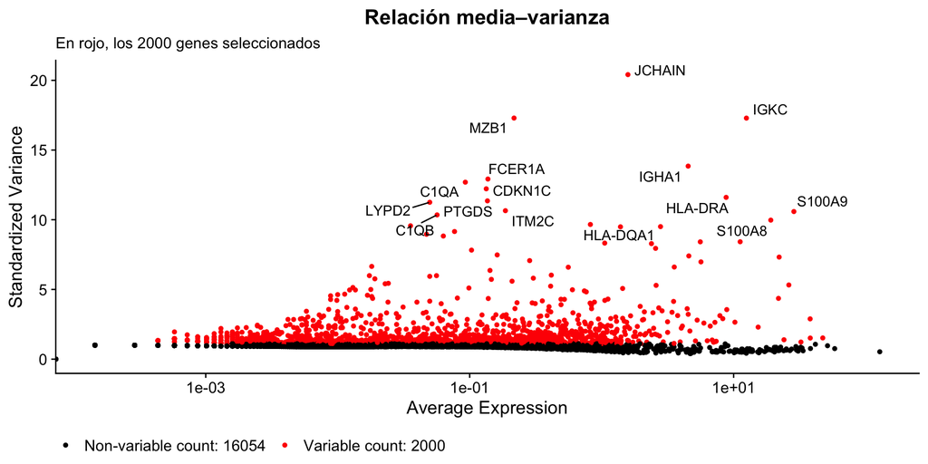

Media contra varianza, un punto por gen. En rojo, los 2.000 seleccionados como altamente variables. Todo lo que venga después —escalamiento, PCA, vecinos, clusters— se calcula solo sobre estos. El número 2.000 es el default de Seurat, no un resultado.

## ScaleData y la tentación de corregir por covariables

Escalamiento

**Qué hace.** Centra cada gen en media 0 y varianza 1 —z-score por gen— para que PCA no quede dominada por los genes de alta expresión.

**Qué se pierde.** Después de escalar, un gen expresado en el 1 % de las células pesa lo mismo que uno expresado en el 60 %.

**Por defecto solo escala los HVGs.** Escalar los 20.000 genes solo hace falta para heatmaps y consume varios GB de RAM.

⚠ Cuidado

#### vars.to.regress

Permite quitar el efecto de una covariable antes de PCA. Es tentador y a veces necesario.

Pero **si la covariable está correlacionada con la biología, corregir por ella borra señal real**. Y el porcentaje mitocondrial lo está: hay tipos celulares genuinamente más mitocondriales.

**Regla:** primero mira si la covariable está estructurando el embedding. Si no lo está, no la corrijas.

## Reducción de dimensionalidad

Segunda parte

20.000 dimensiones no se pueden mirar, y tampoco hace falta.

## PCA: el paso más importante y el que menos atención recibe

PCA

Todo lo que sigue —vecinos, clusters, UMAP, integración— se calcula sobre el espacio de PCA, no sobre los genes.

Cada componente principal es una **combinación lineal de genes**, ordenada por cuánta varianza captura. En un PBMC, las primeras suelen separar linfoide de mieloide, T de B.

PCA es **lineal**, y por eso interpretable: se puede mirar qué genes definen cada componente (`DimHeatmap`, *loadings*).

Es también donde **se filtra ruido**: quedarse con *k* componentes es una forma de *denoising*.

Diagnóstico obligatorio

#### ¿Alguna PC está midiendo algo técnico?

Si una de las primeras PCs correlaciona fuerte (|r| > 0,5) con `nCount_RNA` o `percent.mt`, esa componente está codificando profundidad de secuenciación o estrés celular.

Los clusters que salgan de ahí van a reflejar calidad técnica, no biología.

Son tres líneas de código y casi nadie las mira.

## Qué es exactamente “la dirección de máxima varianza”

PCA · en los datos del curso

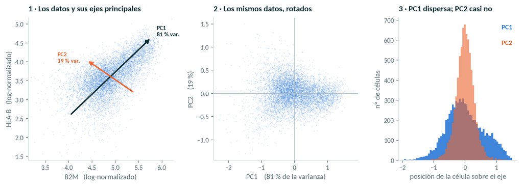

PBMC 10k · las células del curso · dos genes reales de MHC-I. PC1 no es ninguno de los dos ejes medidos: es la dirección en la que las células más se diferencian entre sí. Rotar no cambia los datos, cambia el sistema de coordenadas.

## Qué hay realmente dentro de cada componente

PCA · en los datos del curso

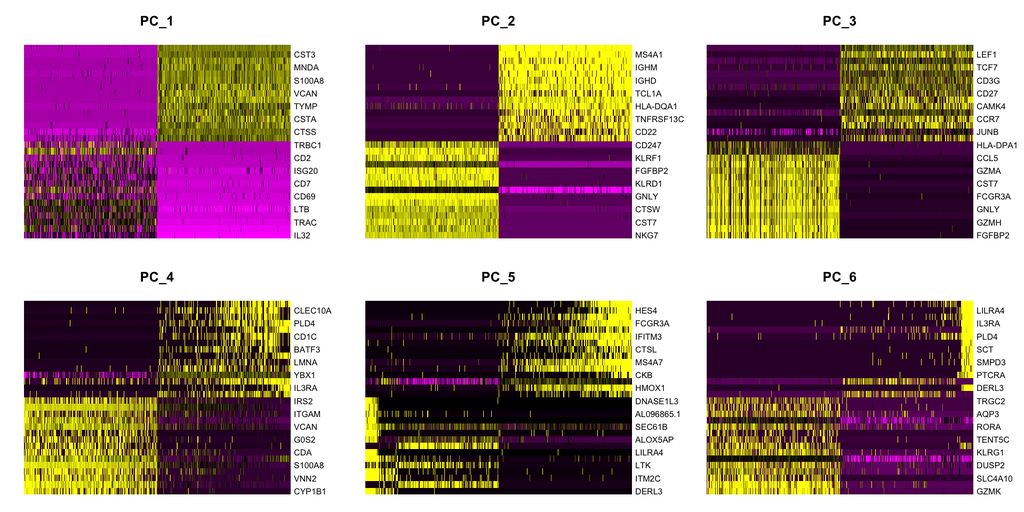

Las 500 células más extremas de cada componente y los genes que más pesan en ella. PC1 separa mieloides (CST3, S100A8, VCAN) de linfoides (CD2, TRAC, IL32); PC2 separa B (MS4A1, IGHM) de NK (GNLY, NKG7). Una componente principal no es un número abstracto: es una lista de genes con signo.

## ¿Cuántas componentes? Cuatro criterios, ninguno definitivo

Reducción de dimensionalidad

Criterio 1

#### El codo

Buscar dónde la curva de desviación estándar se aplana. Desde Seurat 5.5 se grafica directamente el % de varianza explicada.

Criterio 2

#### Varianza acumulada

Con 30 PCs se explica apenas un 20–30 % del total. No estamos tirando el 70 % de la biología: buena parte es ruido de muestreo.

Criterio 3

#### Interpretabilidad

Mirar los genes que definen cada PC. Cuando ya no hay un programa génico reconocible, probablemente es ruido.

Criterio 4

#### Robustez

Repetir con 5, 15 y 50 PCs. Si las poblaciones no cambian, la elección no importa tanto. Si cambian, hay que decir cuál se usó.

**Errar por exceso es más seguro que por defecto.** Las PCs de más aportan ruido; las PCs de menos borran poblaciones enteras.

## El codo y la varianza acumulada dicen cosas distintas

¿Cuántas componentes? · en los datos del curso

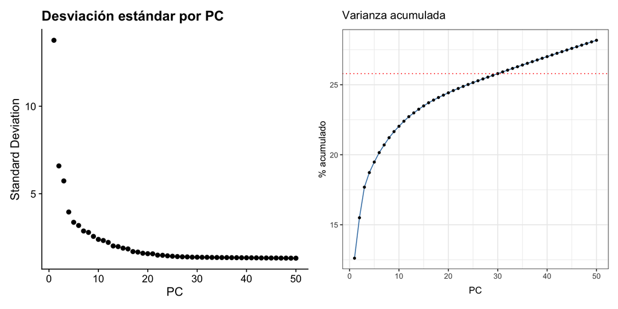

Izquierda: la desviación estándar por componente se aplana alrededor de la 15–20, pero sin ningún corte limpio. Derecha: con 30 componentes se acumula alrededor del 26 % de la varianza. Los dos criterios son legítimos y no coinciden; por eso la decisión se declara, no se descubre.

## ¿Alguna componente está capturando algo que no queremos?

Diagnóstico técnico · en los datos del curso

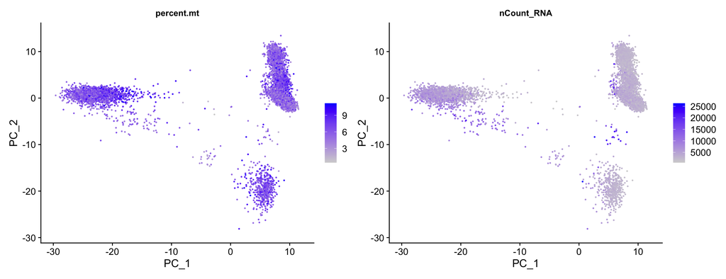

Las dos primeras componentes, coloreadas por porcentaje mitocondrial y por profundidad de secuenciación. Lo que se busca es un gradiente que siga un eje. En estos datos la correlación de PC1 con nCount_RNA es −0,53 y la de PC4 es −0,55: no es catastrófico, pero hay que saberlo antes de interpretar cualquier separación a lo largo de esas componentes.

## t-SNE y UMAP

Embeddings no lineales

Los dos se calculan SOBRE el espacio de PCA. La elección de `dims` de la sección anterior se propaga hasta aquí.

#### t-SNE

- Preserva estructura **local**
- Parámetro clave: `perplexity` (5–50)
- Lento en datasets grandes
- Tiende a separar los grupos con más nitidez
- La distancia entre grupos no significa nada

#### UMAP

- Preserva estructura local y **algo de la global**
- Parámetros clave: `n.neighbors`, `min.dist`
- Rápido, escala a millones de células
- Estándar de facto desde ~2019
- La distancia entre grupos sigue sin significar casi nada

Ninguno de los dos es estable: **sin fijar la semilla, dos corridas dan figuras distintas.**

## t-SNE y UMAP sobre el mismo espacio de PCA

Embeddings · en los datos del curso

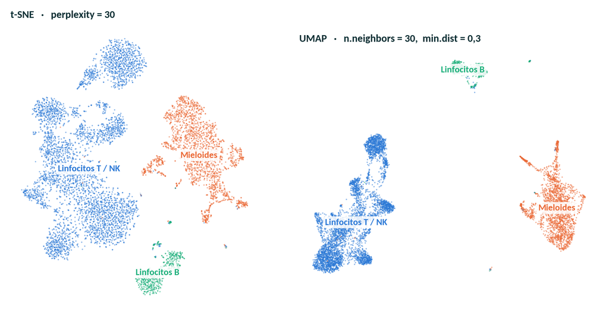

Las MISMAS células y el MISMO espacio de PCA. Los dos separan las mismas tres poblaciones: eso es el resultado. La distancia entre islas, su tamaño y su forma cambian — y nada de eso es cuantitativo.

## Un UMAP es un mapa, no una medición.

La idea que hay que llevarse de esta clase

❌ *“Estas dos islas están lejos → son muy distintas”* — las distancias entre grupos no son cuantitativas.

❌ *“Esta isla es más grande → hay más células o más heterogeneidad”* — UMAP no preserva densidad ni tamaño.

❌ *“Este grupo está en el medio → es un estado de transición”* — hay que verificarlo en el espacio de expresión.

✅ *“Estas células están juntas → se parecen entre sí”* — esto sí, es lo único que UMAP garantiza.

⚠ *“Hay un puente continuo entre A y B”* — sugerente, no probatorio: puede ser doublets o RNA ambiental.

En la práctica vamos a generar **seis UMAPs distintos del mismo dataset** cambiando solo los hiperparámetros. Ninguno es el verdadero.

Publicado el 21 de agosto de 2026: **Bonsai** *(Nature Biotechnology)* reconstruye un ÁRBOL en vez de un mapa 2D. No tiene hiperparámetros y conserva las distancias a todas las escalas. Todavía sin benchmarks independientes.

## Seis UMAPs del mismo dataset

La prueba

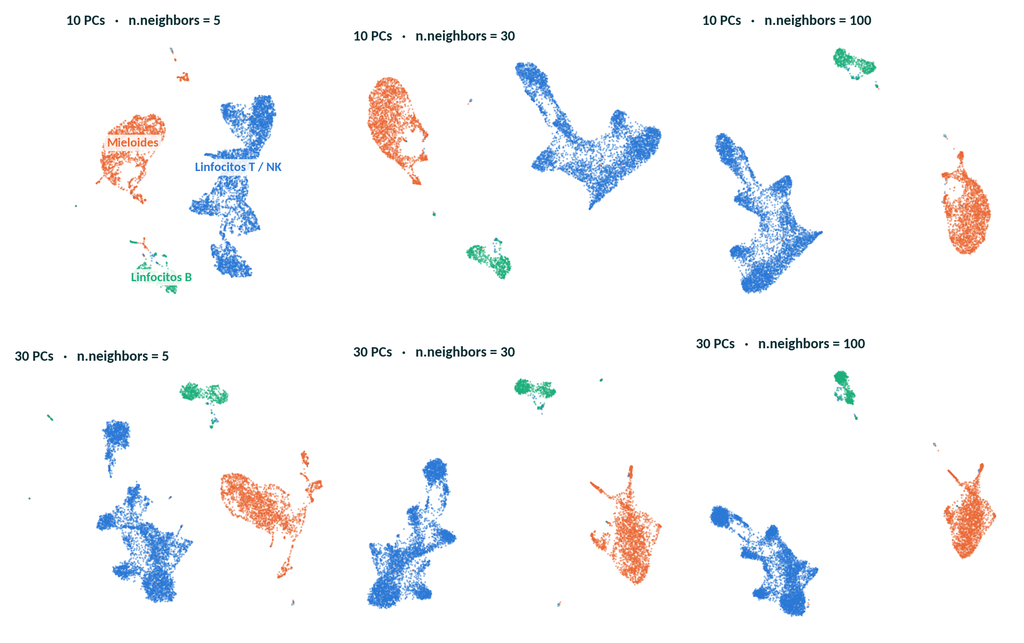

Solo cambian dos hiperparámetros: componentes principales (filas) y `n.neighbors` (columnas). Las tres poblaciones están en los seis. Ninguno de los seis es el verdadero.

## El mismo control, ahora sobre el UMAP

Diagnóstico técnico · en los datos del curso

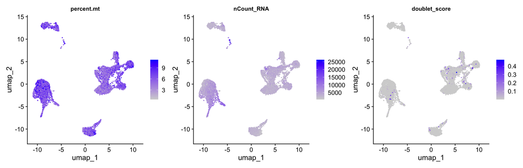

Si una isla del UMAP se explica por porcentaje mitocondrial, por profundidad o por puntaje de doublets, esa isla no es una población celular. Es el control que casi nadie hace y el que evita anotar un artefacto como si fuera un tipo celular nuevo.

## Nueve marcadores canónicos: las poblaciones ya se adivinan

Antes de clusterizar · en los datos del curso

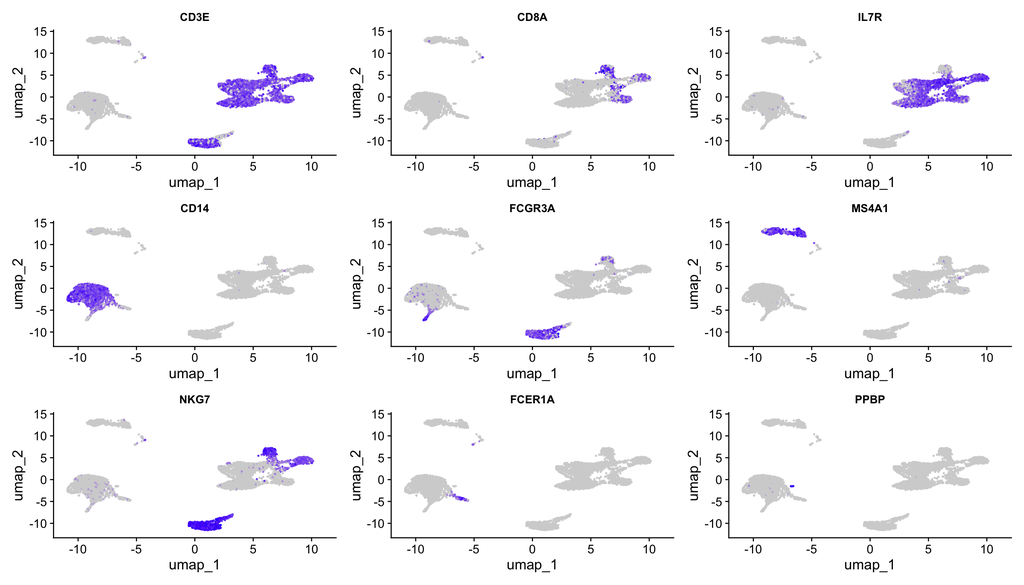

El mismo UMAP, coloreado por la expresión de un gen por panel. CD3E marca linfocitos T, MS4A1 los B, CD14 y FCGR3A los monocitos, NKG7 las NK, PPBP las plaquetas. Todavía no clusterizamos nada — y aun así la estructura está ahí. La clase que viene se trata de cuándo eso es un resultado y cuándo no.

## Cómo se reporta esto en un paper

Consecuencia práctica

Un UMAP sin decir cuántas PCs y qué hiperparámetros se usaron es una **figura irreproducible**.

La semilla aleatoria es parte del método, no un detalle.

El UMAP se usa para **comunicar** un resultado, nunca para **derivarlo**. Las conclusiones cuantitativas salen del espacio de PCA y de los conteos.

`sessionInfo()` en el material suplementario.

Checklist de métodos

#### Lo mínimo que hay que reportar

- Método de normalización y factor de escala
- Número de HVGs y método de selección
- Covariables eliminadas por regresión (o ninguna)
- Número de PCs y criterio usado
- Hiperparámetros de UMAP/t-SNE
- Semilla aleatoria
- Versiones de software

## Cinco cosas

Síntesis

1. **Normalizar** corrige diferencias de profundidad, no diferencias reales de contenido de ARN.
2. **Los HVGs definen el espacio, no la anotación.** Un buen marcador puede no ser un HVG.
3. **Escalar** iguala el peso de los genes; eliminar covariables por regresión es potente y peligroso a la vez.
4. **PCA es el paso decisivo:** todo lo posterior vive en ese espacio.
5. **UMAP y t-SNE preservan vecindad local.** Nada más.

Ahora, al script en RStudio: 70 minutos de práctica. El jueves cortamos este espacio en clusters — y vemos por qué los p-valores que Seurat devuelve para los marcadores **no son p-valores**.

Inicio